# Introduction to text mining

Liliana Millán

November 10, 2017

## Agenda

- Text Mining
- Information retrieval
- Bag of words standard process
- TF-IDF
- Example
- Business case

### Text mining (TM)

- As the name suggests, text mining is a particular type of data mining technique -the mining of text-

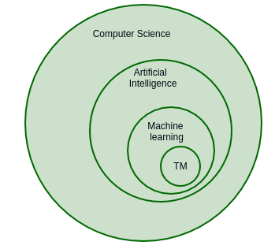

### Information retrieval (IR)

An Information retrieval system conssits of 3 basic elements:

1. A set of documents
2. A query
3. A relevance metric

**Goal:** Sorting the set of documents according to their relevance to the query in question

The non digital reference information system *par excellence* is the library of Congress system

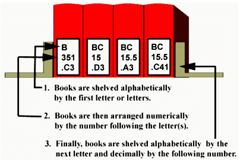

- set of documents: books
- query: searching for a specific theme/book
- relevance: matching books with themes through a unique index

The nowadays reference digital infromation system: Google search engine!

[figure not shown]

- set of documents: web sites on the internet
- query: your words of search
- relevance: page rank -and other algorithms-

### Bag of words

There are a lot of techniques on how to measure relevance on an IR system, the simplest and most common of these is called **bag of words**. The idea is to take each word on a sentence/document as independent from the order in which they appear, and so we will need to *break apart* the order…

With this technique you have to *tokenize* all the words that you have -set of documents and query- how to tokenize them could be done in different ways though, again the simplest way is to tokenize by word.

The standard process for doing text mining with bag of words consists on the following steps:

1. Eliminate accents and punctuation marks *why?*
2. Eliminate numbers (if that make sense in your IR system)
3. Change all letters to lower
4. Eliminate stopwords why?
   - [english](http://snowball.tartarus.org/algorithms/english/stop.txt)
   - [spanish](http://snowball.tartarus.org/algorithms/spanish/stop.txt)
5. Tokenization
6. Apply *stemming* $\rightarrow$ heuristic process for eliminating plurals, and simplify words. There are a lot of algorithms to do stemming, each one is particular for the language of use (optional):
   - [Porter for english](http://snowball.tartarus.org/algorithms/porter/stemmer.html)
   - [Spanish](http://snowball.tartarus.org/algorithms/spanish/stemmer.html)
7. Apply *lemmatization* $\rightarrow$ formal linguistic process to get the *lemma* or root of a word. This algorithms require from linguists (optional).

### TF-IDF

*Term Frequency Inverse Doucment Frequency* is the most common algorithm for measuring relevance on a IR system.

$$tf\_idf_t=tf \cdot log_{10}\frac{N}{df}$$

Where:

- $tf$: Term frequency
- $N$: Number of documents in the set
- $df$: Document frequency

Can you see the pattern?

In case there’s more than one token on the query:

$$tf\_idf{q,d}=\sum_{t \in q} tf\_idf_{t,d}$$

**Process**

1. Clean the documents with the standard process
2. Build a Term Document Matrix (TDM) filling just the term column -set of all the tokens obtained from the previous step- Do you think it matters if we “store” them in alphabetical order?
3. Fill the Term Document Matrix (TDM) with the frequency of appereance of each token on each document of the set

| Term | Doc 1 | Doc 2 | Doc 3 |
| --- | --- | --- | --- |
| something | 0 | 12 | 0 |
| else | 0 | 0 | 2 |

(you can build also a DTM… but is more common to have a TDM)

#### Example

- d1: “Love all, trust a few, do wrong to none.”
- d2: “If music be the food of love, play on.”
- d3: “The course of true love never did run smooth.”
- d4: “Listen to many, speak to a few.”
- d5: “Love is a smoke made with the fume of sighs”
- query: “Speak low, if you speak love”
- **Step 1:** Cleaning the documents and query

Standard process for text mining with bag of words:

1. Eliminate punctuation marks:

d1: “Love all trust a few do wrong to none” d2: “If music be the food of love play on” d3: “The course of true love never did run smooth” d4: “Listen to many speak to a few” d5: “Love is a smoke made with the fume of sighs” query: “Speak low if you speak love”

2. Eliminate numbers: NA
3. To lower

d1: “love all trust a few do wrong to none” d2: “if music be the food of love play on” d3: “the course of true love never did run smooth” d4: “listen to many speak to a few” d5: “love is a smoke made with the fume of sighs” query: “speak low if you speak love”

4. Eliminate [stopwords](http://snowball.tartarus.org/algorithms/english/stop.txt)

d1: “love trust few wrong none” d2: “music food love play” d3: “course true love run smooth” d4: “listen speak few” d5: “love smoke fume sighs” query: “speak low speak love”

5. Tokenization

tokens = {love, trust, few, wrong, none, music, food, play, course, run, smooth, listen, speak, smoke, fume, sighs, low}

6. Stemming - not
7. Lemmatization - not
- **Step 2** Create TDM

TDM:

| Token | d1 | d2 | d3 | d4 | d5 |
| --- | --- | --- | --- | --- | --- |
| love |  |  |  |  |  |
| trust |  |  |  |  |  |
| few |  |  |  |  |  |
| wrong |  |  |  |  |  |
| none |  |  |  |  |  |
| music |  |  |  |  |  |
| food |  |  |  |  |  |
| play |  |  |  |  |  |
| course |  |  |  |  |  |
| run |  |  |  |  |  |
| smooth |  |  |  |  |  |
| listen |  |  |  |  |  |
| speak |  |  |  |  |  |
| smoke |  |  |  |  |  |
| fume |  |  |  |  |  |
| sighs |  |  |  |  |  |
| low |  |  |  |  |  |

- **Step 3** Fill with $tf$

| Token | d1 | d2 | d3 | d4 | d5 |
| --- | --- | --- | --- | --- | --- |
| love | 1 | 1 | 1 | 1 | 1 |
| trust | 1 |  |  |  |  |
| few | 1 |  |  | 1 |  |
| wrong | 1 |  |  |  |  |
| none | 1 |  |  |  |  |
| music |  | 1 |  |  |  |
| food |  | 1 |  |  |  |
| play |  | 1 |  |  |  |
| course |  |  | 1 |  |  |
| run |  |  | 1 |  |  |
| smooth |  |  | 1 |  |  |
| listen |  |  |  | 1 |  |
| speak |  |  |  | 1 |  |
| smoke |  |  |  |  | 1 |
| fume |  |  |  |  | 1 |
| sighs |  |  |  |  | 1 |

- **Step 4** Document frequency

Just add per row

| Token | d1 | d2 | d3 | d4 | d5 | df |
| --- | --- | --- | --- | --- | --- | --- |
| love | 1 | 1 | 1 | 1 | 1 | 5 |
| trust | 1 |  |  |  |  | 1 |
| few | 1 |  |  | 1 |  | 2 |
| wrong | 1 |  |  |  |  | 1 |
| none | 1 |  |  |  |  | 1 |
| music |  | 1 |  |  |  | 1 |
| food |  | 1 |  |  |  | 1 |
| play |  | 1 |  |  |  | 1 |
| course |  |  | 1 |  |  | 1 |
| run |  |  | 1 |  |  | 1 |
| smooth |  |  | 1 |  |  | 1 |
| listen |  |  |  | 1 |  | 1 |
| speak |  |  |  | 1 |  | 1 |
| smoke |  |  |  |  | 1 | 1 |
| fume |  |  |  |  | 1 | 1 |
| sighs |  |  |  |  | 1 | 1 |

- **Step 5** IDF

$$idf=log_{10}\frac{N}{df}$$

$N=5$

| Token | d1 | d2 | d3 | d4 | d5 | df | idf |
| --- | --- | --- | --- | --- | --- | --- | --- |
| love | 1 | 1 | 1 | 1 | 1 | 5 | $log_{10}\frac{5}{5}$ |
| trust | 1 |  |  |  |  | 1 | $log_{10}\frac{5}{1}$ |
| few | 1 |  |  | 1 |  | 2 | $log_{10}\frac{5}{2}$ |
| wrong | 1 |  |  |  |  | 1 | $log_{10}\frac{5}{1}$ |
| none | 1 |  |  |  |  | 1 | $log_{10}\frac{5}{1}$ |
| music |  | 1 |  |  |  | 1 | $log_{10}\frac{5}{1}$ |
| food |  | 1 |  |  |  | 1 | $log_{10}\frac{5}{1}$ |
| play |  | 1 |  |  |  | 1 | $log_{10}\frac{5}{1}$ |
| course |  |  | 1 |  |  | 1 | $log_{10}\frac{5}{1}$ |
| run |  |  | 1 |  |  | 1 | $log_{10}\frac{5}{1}$ |
| smooth |  |  | 1 |  |  | 1 | $log_{10}\frac{5}{1}$ |
| listen |  |  |  | 1 |  | 1 | $log_{10}\frac{5}{1}$ |
| speak |  |  |  | 1 |  | 1 | $log_{10}\frac{5}{1}$ |
| smoke |  |  |  |  | 1 | 1 | $log_{10}\frac{5}{1}$ |
| fume |  |  |  |  | 1 | 1 | $log_{10}\frac{5}{1}$ |
| sighs |  |  |  |  | 1 | 1 | $log_{10}\frac{5}{1}$ |

- **Step 6** TF-IDF for each term on TDM

[output not shown]

[output not shown]

- **Step 7** TF-IDF query terms

query: “speak low speak love”

[output not shown]

- **Step 8** Sum tf-idfs

[output not shown]

- **Step 9** Sort the documents set

[output not shown]

*So according to TF-IDF the document “Listen to many speak to a few” is the most relevant to our query “Speak low, if you speak love”, does that make sense?*

### Business case

#### Problem

- An editorial company wants to *tag* all of its digital content, they (used to) have 13 different brands generating media content from sports to business and everything in between.
- The length of the context varies significatively from brand to brand: ~20 words to ~5,000 words (special investigations)
- The editorial company has a taxonomy -based on the international standard IPTC- of the themes that they normally write about
  - ~3,942 tags
  - 5 levels of abstraction

### BM25 Okapi Best Match

- 3 variables
  - Documents length
  - Query length
  - Frequency of the term on the query
- 3 parameters
  - $k1$ the effect of the term frequency on the document tunning
  - $k2$ the effect of the term frequency on the query tunning
  - $b$ the effect of the document length of the data set tunning

$$\sum_{i\in Q} log\frac{(r_{i} + 0.5)(N-n_{i}-R+r_{i}+0.5)}{(n_{i}-r_{i}+0.5)(R-r_{i}+0.5)}\cdot \frac{(k_{1}+1)f_{i}}{(K+f_{i})} \cdot \frac{(k_{2}+1)qf_{i}}{k_{2}+qf_{i}}$$

$$K=k_{1}\left((1-b)+b\cdot\frac{dl}{avgdl}\right)$$

**Term 1**

$$log\frac{(r_{i} + 0.5)(N-n_{i}-R+r_{i}+0.5)}{(n_{i}-r_{i}+0.5)(R-r_{i}+0.5)}$$

**Term 2**

$$\frac{(k_{1}+1)f_{i}}{(K+f_{i})}$$
$$K=k_{1}\left((1-b)+b\cdot\frac{dl}{avgdl}\right)$$

$k1=[0.0,2.0]$ valor típico $\rightarrow$ 1.2 * $b=[0.0,1.0]$ valor típico $\rightarrow$ 0.75*

* Text Retrieval Conference (TREC)

**Term 3** $k2=[0,1000]$ valor típico $\rightarrow$ 1000 *

$$\frac{(k_{2}+1)qf_{i}}{k_{2}+qf_{i}}$$

* Text Retrieval Conference (TREC)

[IR - BM25 prototype](https://lmillan.shinyapps.io/etiquetador_bm25/)

#### TF-IDF vs BM25

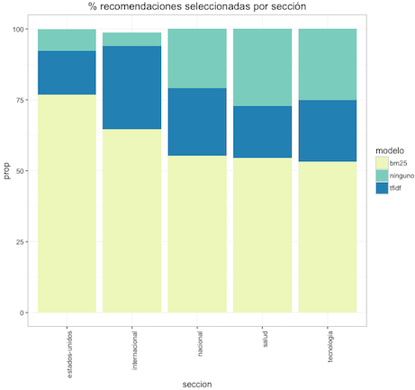

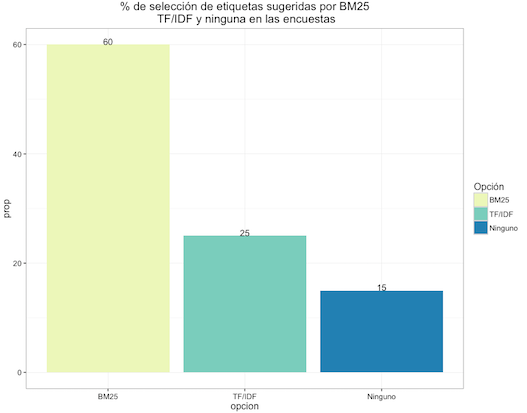

#### Implementation

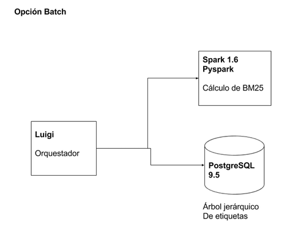

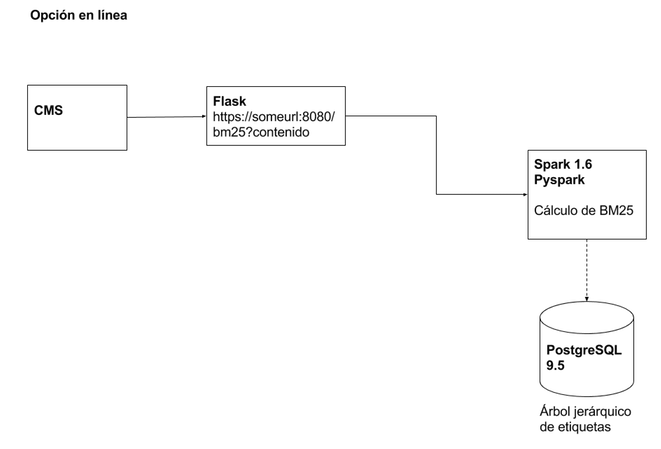

#### Improvements

- Improve the tailored taxonomy by including more themes: health, tecnology and enviromental themes
- BM25F giving specific weights to different structures of the content: heading, abstract, content, …

### Exercises

- Implement the standard process of cleaning text for bag of words
  - Itś better if you implement each step of the process as a method
- Implement the TF-IDF algorithm as the relevance metric
- Test all you methods with the following documents set and query, print the output of each step:
- Sort the documents set with the relevance given by TF-IDF (ascendently)

d1: “Trump believes Putin on Russia meddling, says Mueller may cost lives”

d2: “Tracking Trump: mood swings in Asia and election struggles at home”

d3: “As Trump fawns over Xi, global politics is now a ‘strong man’ game”

d4: “Trump has no comment on Roy Moore because he doesn’t ‘watch much TV’”

d5: “Japan anger over South Korea’s shrimp surprise for Donald Trump”

d6: “Ex- Trump aide Flynn investigated over plot to kidnap Turkish dissident – report”

d7: “Chinese media hails success of Trump’s ‘pilgrimage’ to Beijing”

query: “Trump attacks countries ‘cheating’ America at Apec summit”

1. Just using *raw* python
2. Using scikit-learn

### References

- [Introduction to Information Retrieval](https://nlp.stanford.edu/IR-book/)
- [tf-idf](https://nlp.stanford.edu/IR-book/html/htmledition/term-frequency-and-weighting-1.html)
- [PageRank](http://ilpubs.stanford.edu:8090/422/1/1999-66.pdf)
- [Text mining scikit-learn](http://scikit-learn.org/stable/tutorial/text_analytics/working_with_text_data.html#tokenizing-text-with-scikit-learn)